# Xarray Package

- `Xarray` is an open source Python package.
- Xarray is an efficient & useful package to `read`, `edit`, and `display` spatial data.
- Xarray organizes `gridded`, `multi-dimensional`, `large datasets` and `metadata` in a human friendly format.
- Xarray allow advanced `analytic` & `visualization` methods.
- Xarray labels a multi-dimensional arrays (data) in the form of `dimensions`, `coordinates`, and `attributes`.
- Xarray depends & integrate with other python data analysis packages such as `Pandas` & `numpy`.
- Xarray allows efficent I/O operation of `NetCDF` file & parallel computing.

# Advantages of Xarray over Numpy

- numpy is a powerful but low-level in array manipulation tool.
- numpy axis's only have numbers but no names (it is easy to forget which axis is what, a common source of trivial bugs).
- numpy arrays can't carry metadata (e.g. units), and the data is unstructured (i.e. the coordinates have to be handled separately: another source of bugs).
- Like Pandas, xarray has two fundamental data structures: `DataArray` and `Dataset`:
  - `DataArray` holds a single multi-dimensional variable & it's coordinates.
  - `Dataset` holds multiple variables that potentially share the same coordinates.

# Installation

To install xarray with its recommended dependencies using the conda command line tool:

Required dependencies:

- Python (3.9 or later)
- numpy (1.21 or later)
- packaging (21.3 or later)
- pandas (1.4 or later)

> conda install -c conda-forge xarray dask netCDF4 bottleneck

https://docs.xarray.dev/en/stable/getting-started-guide/installing.html

# Import the xarray package

```python
import xarray as xr
```

```python
import numpy as np
```

```python
d1 = xr.DataArray([3, 2, 5, 7, 6], dims=['x'], coords={'x': [1, 2, 3, 4, 5]})
d1
```

```
<xarray.DataArray (x: 5)>
array([3, 2, 5, 7, 6])
Coordinates:
  * x        (x) int64 1 2 3 4 5
```

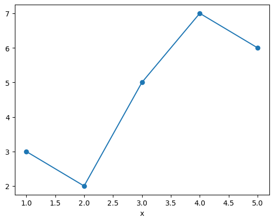

```python
d1.plot(marker='o')
```

# Reading Netcdf file

```python
# Here we’ll use air temperature from the National Center for Environmental Prediction.

# ds = xr.open_dataset("")

ds = xr.tutorial.load_dataset("air_temperature")
ds
```

```
<xarray.Dataset>
Dimensions:  (lat: 25, time: 2920, lon: 53)
Coordinates:
  * lat      (lat) float32 75.0 72.5 70.0 67.5 65.0 ... 25.0 22.5 20.0 17.5 15.0
  * lon      (lon) float32 200.0 202.5 205.0 207.5 ... 322.5 325.0 327.5 330.0
  * time     (time) datetime64[ns] 2013-01-01 ... 2014-12-31T18:00:00
Data variables:
    air      (time, lat, lon) float32 241.2 242.5 243.5 ... 296.5 296.2 295.7
Attributes:
    Conventions:  COARDS
    title:        4x daily NMC reanalysis (1948)
    description:  Data is from NMC initialized reanalysis\n(4x/day).  These a...
    platform:     Model
    references:   http://www.esrl.noaa.gov/psd/data/gridded/data.ncep.reanaly...
```

# Accessing the data

```python
ds.dims
```

```
Frozen({'lat': 25, 'time': 2920, 'lon': 53})
```

```python
ds.coords
```

```
Coordinates:
  * lat      (lat) float32 75.0 72.5 70.0 67.5 65.0 ... 25.0 22.5 20.0 17.5 15.0
  * lon      (lon) float32 200.0 202.5 205.0 207.5 ... 322.5 325.0 327.5 330.0
  * time     (time) datetime64[ns] 2013-01-01 ... 2014-12-31T18:00:00
```

```python
ds.data_vars
```

```
Data variables:
    air      (time, lat, lon) float32 241.2 242.5 243.5 ... 296.5 296.2 295.7
```

```python
# It is possible to loop over the data variables which results each variable name

for varname in ds:
    print(varname)
```

```
air
```

```python
# Individual variable can be accessed using it's name
air_temp = ds['air']
# air_temp = ds.air
```

```python
air_temp.shape
```

```
(2920, 25, 53)
```

```python
air_temp.dims
```

```
('time', 'lat', 'lon')
```

```python
air_temp.coords
```

```
Coordinates:
  * lat      (lat) float32 75.0 72.5 70.0 67.5 65.0 ... 25.0 22.5 20.0 17.5 15.0
  * lon      (lon) float32 200.0 202.5 205.0 207.5 ... 322.5 325.0 327.5 330.0
  * time     (time) datetime64[ns] 2013-01-01 ... 2014-12-31T18:00:00
```

```python
air_temp.lat
```

```
<xarray.DataArray 'lat' (lat: 25)>
array([75. , 72.5, 70. , 67.5, 65. , 62.5, 60. , 57.5, 55. , 52.5, 50. , 47.5,
       45. , 42.5, 40. , 37.5, 35. , 32.5, 30. , 27.5, 25. , 22.5, 20. , 17.5,
       15. ], dtype=float32)
Coordinates:
  * lat      (lat) float32 75.0 72.5 70.0 67.5 65.0 ... 25.0 22.5 20.0 17.5 15.0
Attributes:
    standard_name:  latitude
    long_name:      Latitude
    units:          degrees_north
    axis:           Y
```

```python
air_temp.lon
# air_temp.coords["lon"]
```

```
<xarray.DataArray 'lon' (lon: 53)>
array([200. , 202.5, 205. , 207.5, 210. , 212.5, 215. , 217.5, 220. , 222.5,
       225. , 227.5, 230. , 232.5, 235. , 237.5, 240. , 242.5, 245. , 247.5,
       250. , 252.5, 255. , 257.5, 260. , 262.5, 265. , 267.5, 270. , 272.5,
       275. , 277.5, 280. , 282.5, 285. , 287.5, 290. , 292.5, 295. , 297.5,
       300. , 302.5, 305. , 307.5, 310. , 312.5, 315. , 317.5, 320. , 322.5,
       325. , 327.5, 330. ], dtype=float32)
Coordinates:
  * lon      (lon) float32 200.0 202.5 205.0 207.5 ... 322.5 325.0 327.5 330.0
Attributes:
    standard_name:  longitude
    long_name:      Longitude
    units:          degrees_east
    axis:           X
```

```python
air_temp.time
```

```
<xarray.DataArray 'time' (time: 2920)>
array(['2013-01-01T00:00:00.000000000', '2013-01-01T06:00:00.000000000',
       '2013-01-01T12:00:00.000000000', ..., '2014-12-31T06:00:00.000000000',
       '2014-12-31T12:00:00.000000000', '2014-12-31T18:00:00.000000000'],
      dtype='datetime64[ns]')
Coordinates:
  * time     (time) datetime64[ns] 2013-01-01 ... 2014-12-31T18:00:00
Attributes:
    standard_name:  time
    long_name:      Time
```

```python
air_temp.attrs
```

```
{'long_name': '4xDaily Air temperature at sigma level 995',
 'units': 'degK',
 'precision': 2,
 'GRIB_id': 11,
 'GRIB_name': 'TMP',
 'var_desc': 'Air temperature',
 'dataset': 'NMC Reanalysis',
 'level_desc': 'Surface',
 'statistic': 'Individual Obs',
 'parent_stat': 'Other',
 'actual_range': array([185.16, 322.1 ], dtype=float32)}
```

# Subsetting a dataset by time and space

## Slicing and Dicing

```python
air_temp1 = air_temp[2,:,:]
air_temp1
```

```
<xarray.DataArray 'air' (lat: 25, lon: 53)>
array([[242.29999, 242.2    , 242.29999, ..., 234.29999, 236.09999,
        238.7    ],
       [244.59999, 244.39   , 244.     , ..., 230.29999, 232.     ,
        235.7    ],
       [256.19998, 255.5    , 254.2    , ..., 231.2    , 233.2    ,
        238.2    ],
       ...,
       [295.6    , 295.4    , 295.4    , ..., 296.29   , 295.29   ,
        295.     ],
       [296.19998, 296.5    , 296.29   , ..., 296.4    , 296.     ,
        295.6    ],
       [296.4    , 296.29   , 296.4    , ..., 297.     , 297.     ,
        296.79   ]], dtype=float32)
Coordinates:
  * lat      (lat) float32 75.0 72.5 70.0 67.5 65.0 ... 25.0 22.5 20.0 17.5 15.0
  * lon      (lon) float32 200.0 202.5 205.0 207.5 ... 322.5 325.0 327.5 330.0
    time     datetime64[ns] 2013-01-01T12:00:00
Attributes:
    long_name:     4xDaily Air temperature at sigma level 995
    units:         degK
    precision:     2
    GRIB_id:       11
    GRIB_name:     TMP
    var_desc:      Air temperature
    dataset:       NMC Reanalysis
    level_desc:    Surface
    statistic:     Individual Obs
    parent_stat:   Other
    actual_range:  [185.16 322.1 ]
```

```python
air_temp11 = air_temp.isel(time=0)
air_temp11
```

```
<xarray.DataArray 'air' (lat: 25, lon: 53)>
array([[241.2    , 242.5    , 243.5    , ..., 232.79999, 235.5    ,
        238.59999],
       [243.79999, 244.5    , 244.7    , ..., 232.79999, 235.29999,
        239.29999],
       [250.     , 249.79999, 248.89   , ..., 233.2    , 236.39   ,
        241.7    ],
       ...,
       [296.6    , 296.19998, 296.4    , ..., 295.4    , 295.1    ,
        294.69998],
       [295.9    , 296.19998, 296.79   , ..., 295.9    , 295.9    ,
        295.19998],
       [296.29   , 296.79   , 297.1    , ..., 296.9    , 296.79   ,
        296.6    ]], dtype=float32)
Coordinates:
  * lat      (lat) float32 75.0 72.5 70.0 67.5 65.0 ... 25.0 22.5 20.0 17.5 15.0
  * lon      (lon) float32 200.0 202.5 205.0 207.5 ... 322.5 325.0 327.5 330.0
    time     datetime64[ns] 2013-01-01
Attributes:
    long_name:     4xDaily Air temperature at sigma level 995
    units:         degK
    precision:     2
    GRIB_id:       11
    GRIB_name:     TMP
    var_desc:      Air temperature
    dataset:       NMC Reanalysis
    level_desc:    Surface
    statistic:     Individual Obs
    parent_stat:   Other
    actual_range:  [185.16 322.1 ]
```

# Select specific region

```python
lat_min = ds.lat.min()
lat_max = ds.lat.max()

lat_min, lat_max
```

```
(<xarray.DataArray 'lat' ()>
 array(15.),
 <xarray.DataArray 'lat' ()>
 array(75.))
```

```python
lon_min = ds.lon.min()
lon_max = ds.lon.max()

lon_min, lon_max
```

```
(<xarray.DataArray 'lon' ()>
 array(200.),
 <xarray.DataArray 'lon' ()>
 array(330.))
```

```python
air_sub = air_temp.sel(lat=slice(60,20),lon=slice(250,300))
air_sub
```

```
<xarray.DataArray 'air' (time: 2920, lat: 17, lon: 21)>
array([[[256.19998, 251.2    , 248.7    , ..., 265.1    , 266.79   ,
         268.5    ],
        [261.9    , 255.29999, 251.89   , ..., 263.79   , 266.79   ,
         268.9    ],
        [267.1    , 258.9    , 253.89   , ..., 261.29   , 264.79   ,
         267.6    ],
        ...,
        [290.9    , 287.69998, 284.4    , ..., 294.4    , 294.69998,
         295.     ],
        [294.     , 295.4    , 290.     , ..., 296.6    , 296.79   ,
         296.69998],
        [295.5    , 298.79   , 296.4    , ..., 297.9    , 298.     ,
         298.1    ]],

       [[261.6    , 254.89   , 249.59999, ..., 262.69998, 265.9    ,
         268.69998],
        [266.29   , 258.1    , 251.39   , ..., 260.9    , 265.1    ,
         268.29   ],
        [269.19998, 261.6    , 255.29999, ..., 258.19998, 262.1    ,
         265.6    ],
...
        [295.19   , 293.99   , 285.88998, ..., 297.79   , 297.69   ,
         297.79   ],
        [297.38998, 297.88998, 288.09   , ..., 297.88998, 297.88998,
         297.99   ],
        [296.99   , 297.88998, 292.38998, ..., 299.19   , 298.99   ,
         298.69   ]],

       [[259.29   , 257.19   , 255.59   , ..., 245.98999, 250.09   ,
         256.09   ],
        [264.99   , 262.99   , 261.59   , ..., 245.59   , 248.89   ,
         254.79   ],
        [268.09   , 265.99   , 264.38998, ..., 242.48999, 243.09   ,
         247.89   ],
        ...,
        [294.59   , 295.19   , 292.59   , ..., 297.88998, 297.88998,
         297.99   ],
        [296.29   , 298.99   , 297.29   , ..., 298.88998, 298.88998,
         298.59   ],
        [296.09   , 298.59   , 299.29   , ..., 300.78998, 300.59   ,
         299.88998]]], dtype=float32)
Coordinates:
  * lat      (lat) float32 60.0 57.5 55.0 52.5 50.0 ... 30.0 27.5 25.0 22.5 20.0
  * lon      (lon) float32 250.0 252.5 255.0 257.5 ... 292.5 295.0 297.5 300.0
  * time     (time) datetime64[ns] 2013-01-01 ... 2014-12-31T18:00:00
Attributes:
    long_name:     4xDaily Air temperature at sigma level 995
    units:         degK
    precision:     2
    GRIB_id:       11
    GRIB_name:     TMP
    var_desc:      Air temperature
    dataset:       NMC Reanalysis
    level_desc:    Surface
    statistic:     Individual Obs
    parent_stat:   Other
    actual_range:  [185.16 322.1 ]
```

## Add time selection

```python
air_sub_t1 = air_temp.isel(time=0).sel(lat=slice(60,20),lon=slice(250,300))
air_sub_t1
```

```
<xarray.DataArray 'air' (lat: 17, lon: 21)>
array([[256.19998, 251.2    , 248.7    , 248.     , 247.7    , 247.09999,
        246.39   , 246.2    , 246.79999, 248.29999, 250.59999, 252.7    ,
        253.39   , 252.89   , 252.5    , 254.29999, 258.1    , 262.29   ,
        265.1    , 266.79   , 268.5    ],
       [261.9    , 255.29999, 251.89   , 251.5    , 251.89   , 251.79999,
        251.39   , 250.7    , 249.5    , 248.2    , 248.5    , 250.79999,
        253.09999, 253.59999, 252.7    , 253.     , 255.79999, 259.9    ,
        263.79   , 266.79   , 268.9    ],
       [267.1    , 258.9    , 253.89   , 253.     , 253.5    , 253.29999,
        252.59999, 252.     , 250.79999, 249.29999, 249.5    , 252.09999,
        254.29999, 253.39   , 251.     , 250.59999, 253.29999, 257.5    ,
        261.29   , 264.79   , 267.6    ],
       [269.5    , 262.69998, 256.9    , 254.29999, 253.29999, 251.89   ,
        250.29999, 249.59999, 249.39   , 249.     , 250.     , 253.39   ,
        256.6    , 256.3    , 253.09999, 251.09999, 252.59999, 256.3    ,
        260.19998, 263.6    , 266.19998],
       [269.79   , 267.9    , 263.     , 258.1    , 254.59999, 251.79999,
        249.59999, 249.89   , 252.29999, 254.     , 254.29999, 255.89   ,
        260.     , 263.     , 261.5    , 257.29   , 255.5    , 258.29   ,
        264.     , 268.69998, 270.5    ],
...
       [281.5    , 278.6    , 282.29   , 286.79   , 288.     , 289.     ,
        289.6    , 288.69998, 288.5    , 288.69998, 287.69998, 288.29   ,
        290.5    , 291.1    , 290.29   , 289.9    , 290.29   , 290.69998,
        290.9    , 291.19998, 291.5    ],
       [286.79   , 281.79   , 283.5    , 290.4    , 293.69998, 292.9    ,
        293.     , 293.79   , 293.69998, 293.     , 291.69998, 291.29   ,
        292.29   , 292.9    , 292.4    , 291.69998, 291.9    , 292.29   ,
        292.19998, 292.19998, 292.79   ],
       [290.9    , 287.69998, 284.4    , 288.5    , 295.1    , 296.4    ,
        295.4    , 295.29   , 295.29   , 295.5    , 295.29   , 294.9    ,
        294.5    , 294.5    , 294.69998, 294.29   , 293.79   , 294.     ,
        294.4    , 294.69998, 295.     ],
       [294.     , 295.4    , 290.     , 287.4    , 292.     , 295.6    ,
        296.79   , 296.69998, 296.19998, 296.6    , 296.9    , 297.19998,
        296.4    , 295.5    , 295.79   , 295.9    , 296.     , 296.4    ,
        296.6    , 296.79   , 296.69998],
       [295.5    , 298.79   , 296.4    , 292.1    , 290.79   , 292.5    ,
        297.6    , 299.19998, 297.4    , 297.6    , 297.9    , 298.19998,
        298.1    , 297.79   , 298.1    , 297.1    , 297.1    , 298.     ,
        297.9    , 298.     , 298.1    ]], dtype=float32)
Coordinates:
  * lat      (lat) float32 60.0 57.5 55.0 52.5 50.0 ... 30.0 27.5 25.0 22.5 20.0
  * lon      (lon) float32 250.0 252.5 255.0 257.5 ... 292.5 295.0 297.5 300.0
    time     datetime64[ns] 2013-01-01
Attributes:
    long_name:     4xDaily Air temperature at sigma level 995
    units:         degK
    precision:     2
    GRIB_id:       11
    GRIB_name:     TMP
    var_desc:      Air temperature
    dataset:       NMC Reanalysis
    level_desc:    Surface
    statistic:     Individual Obs
    parent_stat:   Other
    actual_range:  [185.16 322.1 ]
```

- it is convenient to use `isel` to select the time, but it is also possible to specify the date explicitly using `sel`

```python
air_sub_t11 = air_temp.sel(time='2013-01-01', lat=slice(60,20),lon=slice(250,300))
air_sub_t11
```

```
<xarray.DataArray 'air' (time: 4, lat: 17, lon: 21)>
array([[[256.19998, 251.2    , 248.7    , ..., 265.1    , 266.79   ,
         268.5    ],
        [261.9    , 255.29999, 251.89   , ..., 263.79   , 266.79   ,
         268.9    ],
        [267.1    , 258.9    , 253.89   , ..., 261.29   , 264.79   ,
         267.6    ],
        ...,
        [290.9    , 287.69998, 284.4    , ..., 294.4    , 294.69998,
         295.     ],
        [294.     , 295.4    , 290.     , ..., 296.6    , 296.79   ,
         296.69998],
        [295.5    , 298.79   , 296.4    , ..., 297.9    , 298.     ,
         298.1    ]],

       [[261.6    , 254.89   , 249.59999, ..., 262.69998, 265.9    ,
         268.69998],
        [266.29   , 258.1    , 251.39   , ..., 260.9    , 265.1    ,
         268.29   ],
        [269.19998, 261.6    , 255.29999, ..., 258.19998, 262.1    ,
         265.6    ],
...
        [289.69998, 286.4    , 282.69998, ..., 294.5    , 294.4    ,
         294.5    ],
        [295.69998, 296.     , 288.19998, ..., 297.29   , 297.29   ,
         296.69998],
        [296.79   , 298.6    , 293.9    , ..., 298.79   , 298.6    ,
         298.     ]],

       [[262.19998, 259.6    , 255.5    , ..., 262.     , 265.69998,
         269.19998],
        [270.19998, 267.9    , 262.4    , ..., 261.     , 265.5    ,
         269.6    ],
        [273.19998, 272.4    , 268.     , ..., 257.79   , 261.5    ,
         265.9    ],
        ...,
        [292.29   , 290.79   , 286.1    , ..., 295.29   , 295.5    ,
         295.4    ],
        [296.1    , 297.19998, 291.19998, ..., 297.9    , 297.69998,
         297.29   ],
        [297.19998, 299.19998, 296.9    , ..., 299.4    , 298.9    ,
         298.4    ]]], dtype=float32)
Coordinates:
  * lat      (lat) float32 60.0 57.5 55.0 52.5 50.0 ... 30.0 27.5 25.0 22.5 20.0
  * lon      (lon) float32 250.0 252.5 255.0 257.5 ... 292.5 295.0 297.5 300.0
  * time     (time) datetime64[ns] 2013-01-01 ... 2013-01-01T18:00:00
Attributes:
    long_name:     4xDaily Air temperature at sigma level 995
    units:         degK
    precision:     2
    GRIB_id:       11
    GRIB_name:     TMP
    var_desc:      Air temperature
    dataset:       NMC Reanalysis
    level_desc:    Surface
    statistic:     Individual Obs
    parent_stat:   Other
    actual_range:  [185.16 322.1 ]
```

```python
air_sub_t111 = air_temp.sel(time='2013-01-01T12:00:00.000000000', lat=slice(60,20),lon=slice(250,300))
air_sub_t111
```

```
<xarray.DataArray 'air' (lat: 17, lon: 21)>
array([[262.19998, 257.9    , 252.5    , 247.59999, 244.5    , 243.39   ,
        243.59999, 244.7    , 246.29999, 248.39   , 250.39   , 251.59999,
        251.59999, 250.89   , 250.5    , 251.39   , 254.     , 258.     ,
        262.4    , 266.6    , 270.19998],
       [269.9    , 264.5    , 257.19998, 250.79999, 247.29999, 246.39   ,
        247.     , 247.79999, 248.29999, 248.39   , 248.79999, 250.     ,
        251.7    , 252.79999, 253.09999, 253.     , 253.79999, 256.3    ,
        260.69998, 265.9    , 270.1    ],
       [274.     , 269.9    , 263.4    , 257.4    , 253.39   , 251.5    ,
        251.09999, 251.59999, 251.7    , 250.79999, 249.79999, 250.     ,
        251.     , 251.79999, 252.09999, 252.5    , 253.29999, 254.79999,
        257.5    , 261.79   , 266.     ],
       [273.69998, 270.9    , 265.69998, 261.     , 257.69998, 255.39   ,
        253.89   , 253.7    , 253.59999, 252.39   , 250.79999, 250.5    ,
        251.39   , 252.2    , 252.39   , 252.89   , 253.89   , 254.79999,
        256.3    , 259.29   , 263.1    ],
       [269.9    , 267.6    , 262.4    , 257.9    , 256.     , 254.7    ,
        253.     , 253.09999, 255.59999, 256.5    , 253.5    , 249.59999,
        248.89   , 251.5    , 254.7    , 256.6    , 257.29   , 258.29   ,
        260.9    , 264.69998, 267.9    ],
...
       [270.     , 270.1    , 273.29   , 277.4    , 280.6    , 284.79   ,
        289.1    , 290.5    , 291.19998, 291.29   , 288.4    , 286.79   ,
        290.29   , 293.     , 292.5    , 291.9    , 291.29   , 290.79   ,
        291.29   , 291.69998, 292.     ],
       [276.5    , 272.6    , 275.9    , 282.9    , 287.6    , 291.29   ,
        294.5    , 294.79   , 294.29   , 294.1    , 291.69998, 289.6    ,
        292.     , 294.4    , 293.4    , 292.4    , 292.29   , 292.19998,
        292.1    , 291.79   , 292.1    ],
       [289.69998, 286.4    , 282.69998, 284.     , 290.4    , 295.6    ,
        296.1    , 295.29   , 296.     , 296.69998, 295.79   , 294.5    ,
        294.79   , 295.29   , 294.79   , 294.79   , 295.     , 294.6    ,
        294.5    , 294.4    , 294.5    ],
       [295.69998, 296.     , 288.19998, 281.9    , 287.1    , 295.69998,
        298.1    , 296.19998, 295.5    , 296.29   , 297.4    , 297.9    ,
        297.     , 296.29   , 296.29   , 296.6    , 296.79   , 296.79   ,
        297.29   , 297.29   , 296.69998],
       [296.79   , 298.6    , 293.9    , 286.29   , 284.5    , 289.79   ,
        296.     , 296.     , 294.79   , 296.79   , 298.     , 298.1    ,
        297.9    , 298.1    , 298.4    , 297.69998, 297.79   , 298.6    ,
        298.79   , 298.6    , 298.     ]], dtype=float32)
Coordinates:
  * lat      (lat) float32 60.0 57.5 55.0 52.5 50.0 ... 30.0 27.5 25.0 22.5 20.0
  * lon      (lon) float32 250.0 252.5 255.0 257.5 ... 292.5 295.0 297.5 300.0
    time     datetime64[ns] 2013-01-01T12:00:00
Attributes:
    long_name:     4xDaily Air temperature at sigma level 995
    units:         degK
    precision:     2
    GRIB_id:       11
    GRIB_name:     TMP
    var_desc:      Air temperature
    dataset:       NMC Reanalysis
    level_desc:    Surface
    statistic:     Individual Obs
    parent_stat:   Other
    actual_range:  [185.16 322.1 ]
```

## Slice for the time dimension

```python
air_sub_3mon = air_temp.sel(time=slice('2013-01-01','2013-03-31'), lat=slice(60,20),lon=slice(250,300))
air_sub_3mon
```

```
<xarray.DataArray 'air' (time: 360, lat: 17, lon: 21)>
array([[[256.19998, 251.2    , 248.7    , ..., 265.1    , 266.79   ,
         268.5    ],
        [261.9    , 255.29999, 251.89   , ..., 263.79   , 266.79   ,
         268.9    ],
        [267.1    , 258.9    , 253.89   , ..., 261.29   , 264.79   ,
         267.6    ],
        ...,
        [290.9    , 287.69998, 284.4    , ..., 294.4    , 294.69998,
         295.     ],
        [294.     , 295.4    , 290.     , ..., 296.6    , 296.79   ,
         296.69998],
        [295.5    , 298.79   , 296.4    , ..., 297.9    , 298.     ,
         298.1    ]],

       [[261.6    , 254.89   , 249.59999, ..., 262.69998, 265.9    ,
         268.69998],
        [266.29   , 258.1    , 251.39   , ..., 260.9    , 265.1    ,
         268.29   ],
        [269.19998, 261.6    , 255.29999, ..., 258.19998, 262.1    ,
         265.6    ],
...
        [294.4    , 295.19998, 291.1    , ..., 293.69998, 294.19998,
         294.5    ],
        [296.29   , 299.4    , 294.79   , ..., 296.29   , 296.6    ,
         296.9    ],
        [296.     , 298.     , 295.79   , ..., 297.79   , 297.5    ,
         298.1    ]],

       [[261.29   , 259.5    , 258.6    , ..., 270.29   , 269.19998,
         269.1    ],
        [264.19998, 261.69998, 260.4    , ..., 271.79   , 271.5    ,
         271.4    ],
        [268.5    , 264.69998, 262.     , ..., 270.79   , 271.4    ,
         271.9    ],
        ...,
        [300.1    , 303.     , 300.1    , ..., 294.5    , 295.1    ,
         295.1    ],
        [296.6    , 303.28998, 304.1    , ..., 296.79   , 297.     ,
         297.     ],
        [295.9    , 299.     , 302.19998, ..., 298.4    , 298.19998,
         298.19998]]], dtype=float32)
Coordinates:
  * lat      (lat) float32 60.0 57.5 55.0 52.5 50.0 ... 30.0 27.5 25.0 22.5 20.0
  * lon      (lon) float32 250.0 252.5 255.0 257.5 ... 292.5 295.0 297.5 300.0
  * time     (time) datetime64[ns] 2013-01-01 ... 2013-03-31T18:00:00
Attributes:
    long_name:     4xDaily Air temperature at sigma level 995
    units:         degK
    precision:     2
    GRIB_id:       11
    GRIB_name:     TMP
    var_desc:      Air temperature
    dataset:       NMC Reanalysis
    level_desc:    Surface
    statistic:     Individual Obs
    parent_stat:   Other
    actual_range:  [185.16 322.1 ]
```

# Extracting single coordinate:

- when using `sel` method it must either correspond to an exact value or the `method` argument must be used

```python
air_point1 = air_temp.sel(lat=50., lon=260.)
air_point1
```

```
<xarray.DataArray 'air' (time: 2920)>
array([254.59999, 252.89   , 256.     , ..., 258.69   , 260.38998,
       261.49   ], dtype=float32)
Coordinates:
    lat      float32 50.0
    lon      float32 260.0
  * time     (time) datetime64[ns] 2013-01-01 ... 2014-12-31T18:00:00
Attributes:
    long_name:     4xDaily Air temperature at sigma level 995
    units:         degK
    precision:     2
    GRIB_id:       11
    GRIB_name:     TMP
    var_desc:      Air temperature
    dataset:       NMC Reanalysis
    level_desc:    Surface
    statistic:     Individual Obs
    parent_stat:   Other
    actual_range:  [185.16 322.1 ]
```

```python
air_point2 = air_temp.sel(lat=51., lon=261., method='nearest')
air_point2
```

```
<xarray.DataArray 'air' (time: 2920)>
array([254.59999, 252.89   , 256.     , ..., 258.69   , 260.38998,
       261.49   ], dtype=float32)
Coordinates:
    lat      float32 50.0
    lon      float32 260.0
  * time     (time) datetime64[ns] 2013-01-01 ... 2014-12-31T18:00:00
Attributes:
    long_name:     4xDaily Air temperature at sigma level 995
    units:         degK
    precision:     2
    GRIB_id:       11
    GRIB_name:     TMP
    var_desc:      Air temperature
    dataset:       NMC Reanalysis
    level_desc:    Surface
    statistic:     Individual Obs
    parent_stat:   Other
    actual_range:  [185.16 322.1 ]
```

# Plotting with xarray

- `xarray` library has an inbuilt plot function that is a thin wrapper around the matplotlib library.
- `xarray's` plotting capabilities are centered around DataArray objects.

## 2D Plot

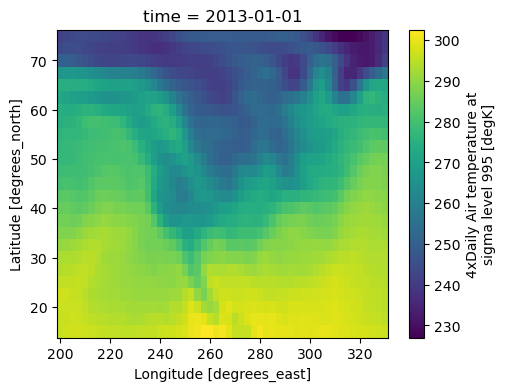

```python
air_temp.isel(time=0).plot(size=4)
```

## Pcolormesh

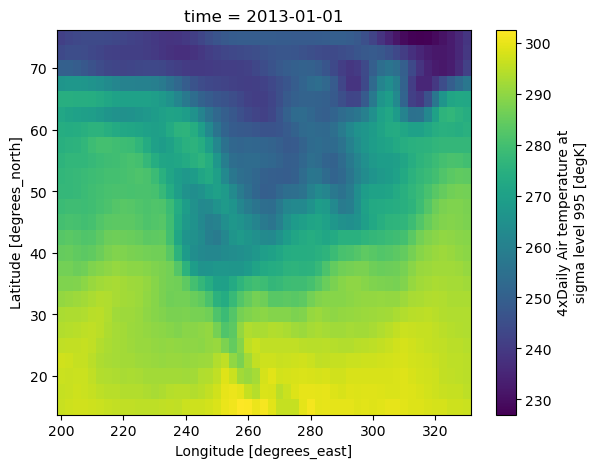

```python
air_2d = air_temp.isel(time=0)
air_2d.plot.pcolormesh(size=5)
```

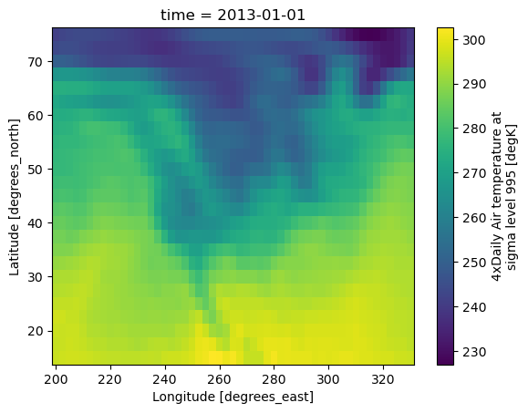

```python
air_temp[0,:,:].plot()
```

## Contourf

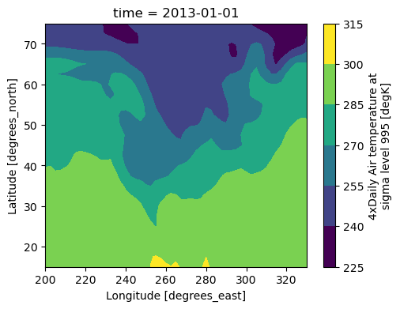

```python
air_2d.plot.contourf(size=4)
```

## Contour

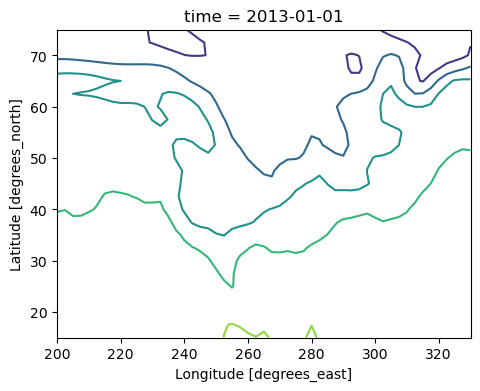

```python
air_2d.plot.contour(size=4)
```

## Revert the axis direction

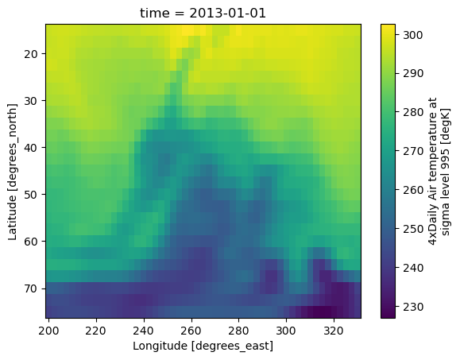

```python
air_2d.plot(yincrease=False)
```

## Plotting with missing values

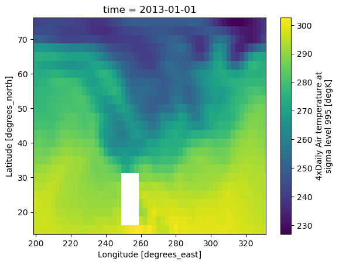

```python
bad_air2d = air_2d.copy()

bad_air2d[dict(lat=slice(18, 24), lon=slice(20, 24))] = np.nan

bad_air2d.plot()
```

## Calling Matplotlib functionality

```python
import matplotlib.pyplot as plt
```

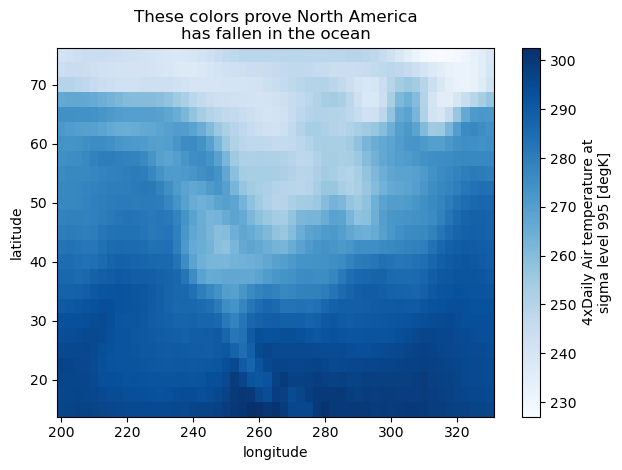

```python
air_2d.plot(cmap=plt.cm.Blues)
plt.title("These colors prove North America\nhas fallen in the ocean")
plt.ylabel("latitude")
plt.xlabel("longitude")
plt.tight_layout()
plt.draw()
```

## Adjust the color scale: Robust

- Outliers often have an extreme effect on the output of the plot.
- The easy way to visualize the data without the outliers is to pass the parameter `robust=True`
- This will use the 2nd and 98th percentiles of the data to compute the color limits

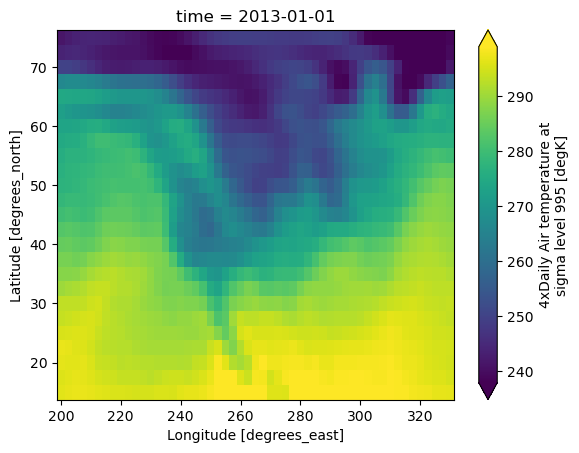

```python
air_2d.plot(robust=True)
```

## Discrete Colormaps

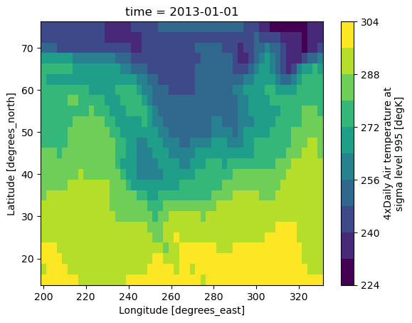

```python
air_2d.plot(levels=12)
```

## Specify the boundaries of the discrete colormap

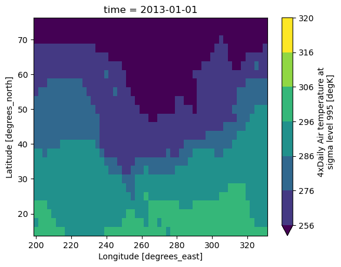

```python
air_2d.plot(levels=[256, 276, 286, 296, 306, 316, 320])
```

## List of discrete colors through the colors argument:

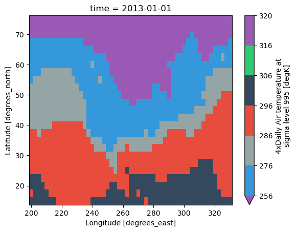

```python
color_list = ["#9b59b6", "#3498db", "#95a5a6", "#e74c3c", "#34495e", "#2ecc71"]
air_2d.plot(levels=[256, 276, 286, 296, 306, 316, 320], colors=color_list)
```

## Faceting

- Faceting here refers to splitting an array along one or two dimensions and plotting each group.
- First try to reduces the size of the data
- For example, let's slice the data

```python
air_temp11 = air_temp.sel(time=slice('2013-01-01','2013-03-31'), lat=slice(60,20), lon=slice(250,300))
air_temp11
```

```
<xarray.DataArray 'air' (time: 360, lat: 17, lon: 21)>
array([[[256.19998, 251.2    , 248.7    , ..., 265.1    , 266.79   ,
         268.5    ],
        [261.9    , 255.29999, 251.89   , ..., 263.79   , 266.79   ,
         268.9    ],
        [267.1    , 258.9    , 253.89   , ..., 261.29   , 264.79   ,
         267.6    ],
        ...,
        [290.9    , 287.69998, 284.4    , ..., 294.4    , 294.69998,
         295.     ],
        [294.     , 295.4    , 290.     , ..., 296.6    , 296.79   ,
         296.69998],
        [295.5    , 298.79   , 296.4    , ..., 297.9    , 298.     ,
         298.1    ]],

       [[261.6    , 254.89   , 249.59999, ..., 262.69998, 265.9    ,
         268.69998],
        [266.29   , 258.1    , 251.39   , ..., 260.9    , 265.1    ,
         268.29   ],
        [269.19998, 261.6    , 255.29999, ..., 258.19998, 262.1    ,
         265.6    ],
...
        [294.4    , 295.19998, 291.1    , ..., 293.69998, 294.19998,
         294.5    ],
        [296.29   , 299.4    , 294.79   , ..., 296.29   , 296.6    ,
         296.9    ],
        [296.     , 298.     , 295.79   , ..., 297.79   , 297.5    ,
         298.1    ]],

       [[261.29   , 259.5    , 258.6    , ..., 270.29   , 269.19998,
         269.1    ],
        [264.19998, 261.69998, 260.4    , ..., 271.79   , 271.5    ,
         271.4    ],
        [268.5    , 264.69998, 262.     , ..., 270.79   , 271.4    ,
         271.9    ],
        ...,
        [300.1    , 303.     , 300.1    , ..., 294.5    , 295.1    ,
         295.1    ],
        [296.6    , 303.28998, 304.1    , ..., 296.79   , 297.     ,
         297.     ],
        [295.9    , 299.     , 302.19998, ..., 298.4    , 298.19998,
         298.19998]]], dtype=float32)
Coordinates:
  * lat      (lat) float32 60.0 57.5 55.0 52.5 50.0 ... 30.0 27.5 25.0 22.5 20.0
  * lon      (lon) float32 250.0 252.5 255.0 257.5 ... 292.5 295.0 297.5 300.0
  * time     (time) datetime64[ns] 2013-01-01 ... 2013-03-31T18:00:00
Attributes:
    long_name:     4xDaily Air temperature at sigma level 995
    units:         degK
    precision:     2
    GRIB_id:       11
    GRIB_name:     TMP
    var_desc:      Air temperature
    dataset:       NMC Reanalysis
    level_desc:    Surface
    statistic:     Individual Obs
    parent_stat:   Other
    actual_range:  [185.16 322.1 ]
```

```python
air_sub_03d = air_temp.sel(time=slice('2013-01-01','2013-01-03'), lat=slice(60,20),lon=slice(250,300))
air_sub_03d
```

```
<xarray.DataArray 'air' (time: 12, lat: 17, lon: 21)>
array([[[256.19998, 251.2    , 248.7    , ..., 265.1    , 266.79   ,
         268.5    ],
        [261.9    , 255.29999, 251.89   , ..., 263.79   , 266.79   ,
         268.9    ],
        [267.1    , 258.9    , 253.89   , ..., 261.29   , 264.79   ,
         267.6    ],
        ...,
        [290.9    , 287.69998, 284.4    , ..., 294.4    , 294.69998,
         295.     ],
        [294.     , 295.4    , 290.     , ..., 296.6    , 296.79   ,
         296.69998],
        [295.5    , 298.79   , 296.4    , ..., 297.9    , 298.     ,
         298.1    ]],

       [[261.6    , 254.89   , 249.59999, ..., 262.69998, 265.9    ,
         268.69998],
        [266.29   , 258.1    , 251.39   , ..., 260.9    , 265.1    ,
         268.29   ],
        [269.19998, 261.6    , 255.29999, ..., 258.19998, 262.1    ,
         265.6    ],
...
        [290.69998, 287.79   , 284.69998, ..., 295.5    , 295.19998,
         294.69998],
        [295.69998, 295.19998, 288.29   , ..., 297.79   , 297.19998,
         296.29   ],
        [297.9    , 298.1    , 292.9    , ..., 298.4    , 298.29   ,
         298.1    ]],

       [[269.5    , 269.79   , 269.4    , ..., 251.     , 257.5    ,
         264.4    ],
        [271.4    , 272.1    , 273.     , ..., 250.2    , 256.5    ,
         263.9    ],
        [274.5    , 273.19998, 273.     , ..., 249.2    , 253.7    ,
         260.9    ],
        ...,
        [291.1    , 288.79   , 287.1    , ..., 295.9    , 295.4    ,
         295.     ],
        [295.79   , 295.79   , 291.5    , ..., 298.29   , 297.79   ,
         297.1    ],
        [297.29   , 298.6    , 296.1    , ..., 299.5    , 299.19998,
         299.     ]]], dtype=float32)
Coordinates:
  * lat      (lat) float32 60.0 57.5 55.0 52.5 50.0 ... 30.0 27.5 25.0 22.5 20.0
  * lon      (lon) float32 250.0 252.5 255.0 257.5 ... 292.5 295.0 297.5 300.0
  * time     (time) datetime64[ns] 2013-01-01 ... 2013-01-03T18:00:00
Attributes:
    long_name:     4xDaily Air temperature at sigma level 995
    units:         degK
    precision:     2
    GRIB_id:       11
    GRIB_name:     TMP
    var_desc:      Air temperature
    dataset:       NMC Reanalysis
    level_desc:    Surface
    statistic:     Individual Obs
    parent_stat:   Other
    actual_range:  [185.16 322.1 ]
```

```python
t = air_sub_03d.isel(time=slice(0, 12, 1))
t.coords
```

```
Coordinates:
  * lat      (lat) float32 60.0 57.5 55.0 52.5 50.0 ... 30.0 27.5 25.0 22.5 20.0
  * lon      (lon) float32 250.0 252.5 255.0 257.5 ... 292.5 295.0 297.5 300.0
  * time     (time) datetime64[ns] 2013-01-01 ... 2013-01-03T18:00:00
```

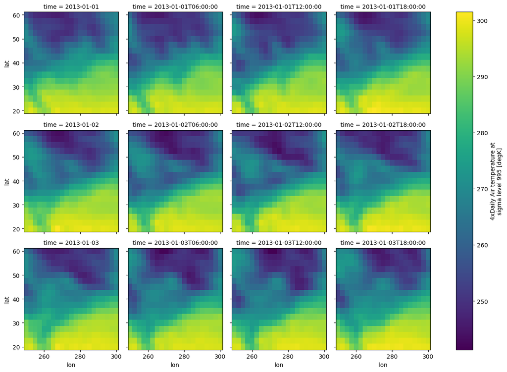

```python
g_simple = t.plot(x="lon", y="lat", col="time", col_wrap=4)
```

## Faceting also works for line plots

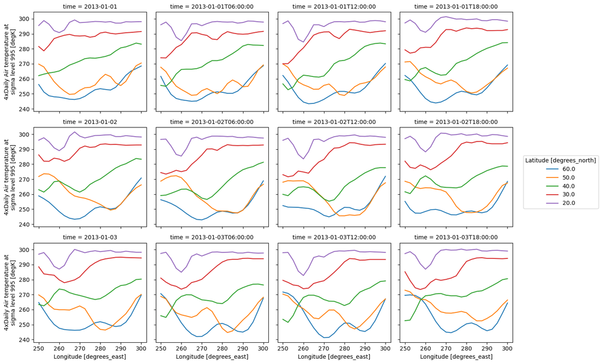

```python
g_simple_line = t.isel(lat=slice(0, None, 4)).plot(x="lon", hue="lat", col="time", col_wrap=4)
```

## Reduce the dimensionality

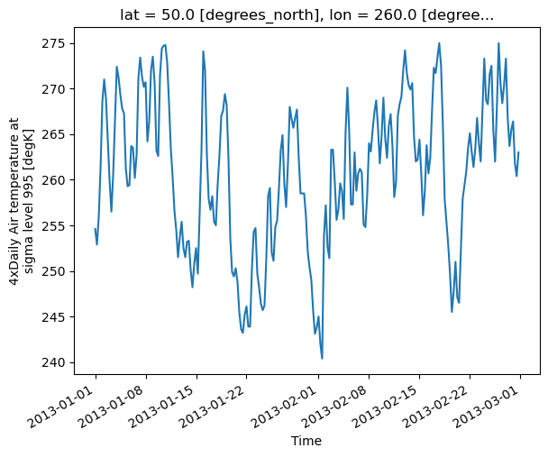

```python
air_temp.sel(time=slice('2013-01','2013-02')).sel(lat=51, lon=261, method='nearest').plot(size=5)
```

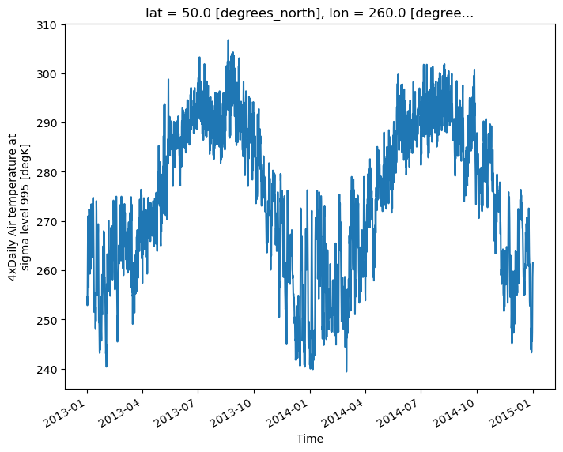

```python
air_1d = air_temp.sel(lat=50., lon=260.)
air_1d.plot(size=6)
```

## Slice the plot

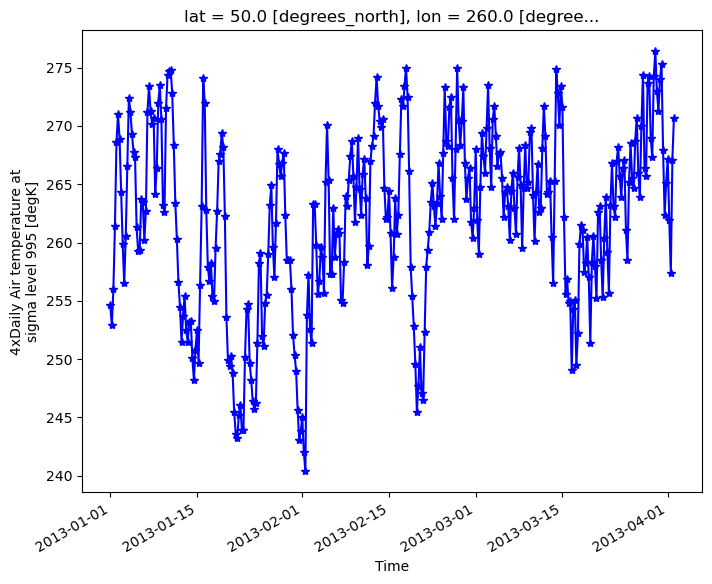

```python
air_1d[:365].plot.line("b-*", size=6)
```

## Some moification

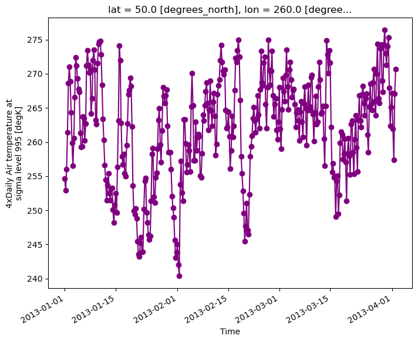

```python
air_1d[:365].plot.line(color="purple", marker="o", size =6)
```

## Controlling the figure size

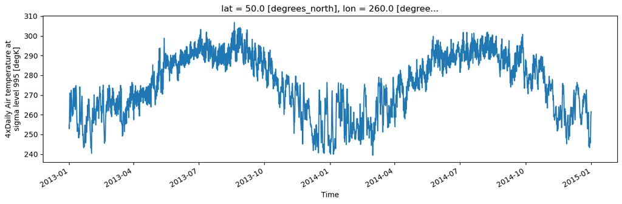

```python
air_1d.plot(aspect=3, size=4)
plt.tight_layout()
```

## Single lon and varying lat

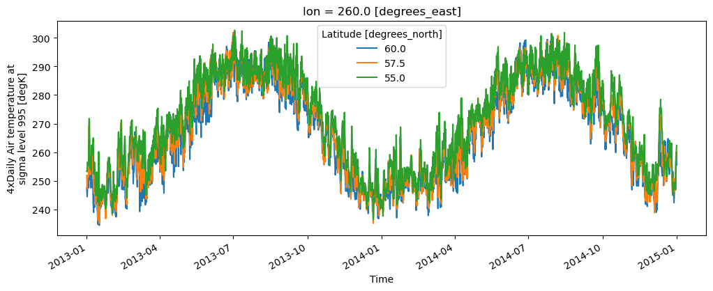

```python
air_temp.sel(lon=260, lat=[60.0, 57.5, 55.0]).plot.line(x="time", aspect=3, size=4)
# air_temp.sel(lon=260, lat=[60.0, 57.5, 55.0]).plot.line(hue='lat',  aspect=3, size=5)
```

## Calculate the mean in time dimension for all locations

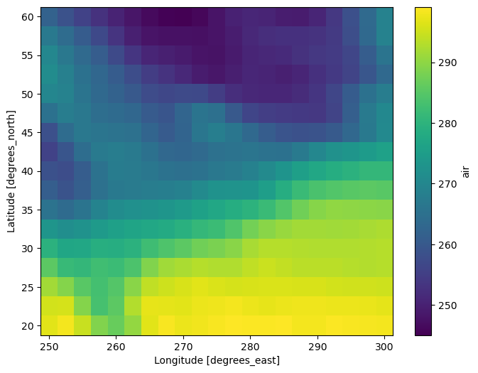

```python
t.mean(dim='time').plot(size=6)
```

## Plot seasonal mean

```
<xarray.plot.facetgrid.FacetGrid at 0x7fc43c1cd780>
```

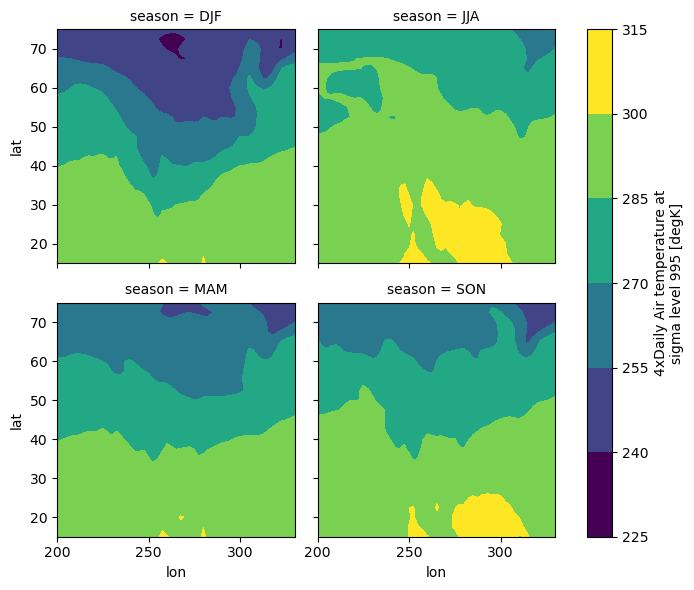

```python
air_temp.groupby('time.season').mean(dim='time').plot.contourf(col='season', col_wrap=2)
```

```
<xarray.plot.facetgrid.FacetGrid at 0x7fc43c34f400>
```

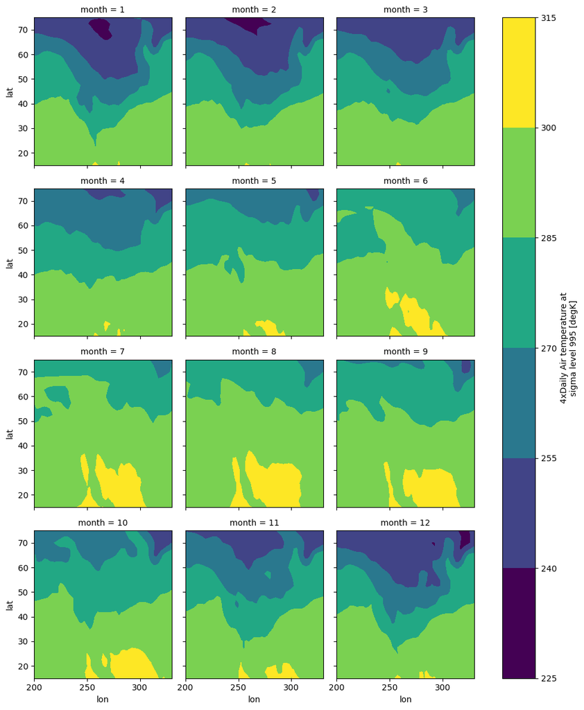

```python
air_temp.groupby('time.month').mean(dim='time').plot.contourf(col='month', col_wrap=3)
```

## Saving data to netCDF

```python
air_temp.to_netcdf('cliped_tsa.nc')
```

### Saving netCDF file allows compression

```python
air_temp.to_netcdf('tas_compressed.nc', encoding=air_temp.encoding.update({'zlib': True, 'complevel': 4}))
```

```python
!ls -lh
```

```
total 30M
-rw-rw-r-- 1 yoni yoni 7.5M Mar 13 09:32  cliped_tsa.nc
-rw-rw-r-- 1 yoni yoni 1.4M Mar 13 07:23  Clipping_Netcdf_With_Salem_Library.html
-rw-rw-r-- 1 yoni yoni 780K Mar 13 07:23 'Clipping Netcdf With Salem Library.ipynb'
-rw-rw-r-- 1 yoni yoni  224 Mar 12 20:57  data_npy.npy
-rw-rw-r-- 1 yoni yoni 1.3K Mar 12 22:48  data_npz1.npz
-rw-rw-r-- 1 yoni yoni  835 Mar 12 22:48  data_npz2.npz
-rw-rw-r-- 1 yoni yoni 6.9K Mar 12 22:48  data_npz3.npz
-rw-rw-r-- 1 yoni yoni  300 Mar 12 22:48  d.csv
-rw-rw-r-- 1 yoni yoni 1.3M Mar 13 05:48  ECMWF_temp2m.nc
-rw-rw-r-- 1 yoni yoni 709K Mar 13 06:38  Mapping_Geographical_Data_with_Basemap.html
-rw-rw-r-- 1 yoni yoni 4.9M Mar 13 06:43 'Mapping Geographical Data with Basemap.ipynb'
-rw-rw-r-- 1 yoni yoni 5.6M Mar 13 06:40  Mapping_Geographical_Data_with_Basemap_Sol.html
-rw-rw-r-- 1 yoni yoni 273K Mar 13 07:23  rfe_etet
-rw-rw-r-- 1 yoni yoni  19K Mar 12 22:48  surface_dataset.nc
-rw-rw-r-- 1 yoni yoni 259K Oct  2 19:59  tamsat_2019_june.nc
-rw-rw-r-- 1 yoni yoni 4.6M Mar 13 09:32  tas_compressed.nc
-rw-rw-r-- 1 yoni yoni 650K Mar 12 22:49  Write_netCDF_Xarray.html
-rw-rw-r-- 1 yoni yoni  74K Mar 13 04:55  Write_netCDF_Xarray.ipynb
-rw-rw-r-- 1 yoni yoni 2.2M Mar 10 14:45  Xarray.ipynb
```